# Increasing Access to Electricity with DER-Powered Microgrids

DATA 510 Data Science Capstone, Summer 2026

Authors

Hayden Coke

Logan MacFarland

# Abstract

When communities lack access to reliable power, their most vulnerable members may risk losing access to medical care, heating and cooling, cooking, and other necessities. These interruptions can range from inconvenient to life threatening. Using Distributed Energy Resources (DER), communities in need of more reliable access to power can install a microgrid that connects to their main power grid and disconnects in the event of a power failure in the main grid, ensuring minimal interruption. Our research project identifies zip codes that may benefit from DER-powered microgrids, and how effective wind and solar power would be at each location.

# Introduction and Background

In a world with an ever increasing reliance on electricity, the demand for energy is not always met by our current electrical grid infrastructure. Power grids are susceptible to natural disasters or weather events that make them fallible and unreliable. Lack of reliable access to heat and electricity and pose health and safety risks, especially to vulnerable populations (Kerby et al. 2025). One method of increasing energy resiliency is the use of onsite energy installation, also known as “behind-the-meter” systems, which produce and consume power on-site rather than solely consuming power transmitted through an electrical grid. Microgrids are a form of onsite energy installation that can provide power to entire communities in a more reliable and efficient manner than traditional grid connection, and are typically powered by solar panels, wind turbines, backup batteries, and/or diesel generators. Microgrids can connect to the main utility grid and can disconnect when the main grid experiences an outage, ensuring minimal interruption to the facilities powered by the microgrid (*Solar Integration Distributed Energy Resources and Microgrids Basics* 2020).

This research project seeks to answer the question: which zip codes may benefit from the installation of microgrids powered by Distributed Energy Resources such as wind and solar?

Answering this question involves examining geographic characteristics of each zip code, such as annual solar radiation and wind speed, as well as human-centric characteristics such as energy demand and vulnerability to power outage. The goal of this project is to create a tool that urban planners, utility companies, or community members can use to evaluate how well their area might suit microgrid installation, and how this suitability compares to other areas.

# Data

All of our datasets came from publicly available sources. Our sources that depended on API requests required access tokens, which were free to acquire. Data acquired through API calls were stored as CSV files prior to ingestion. Once all necessary data was acquired, each dataset was uploaded to a PostgreSQL database, where it could be queried and joined with other datasets. This produced a final dataset of 43,585 zip codes, but filtering to only the continental U.S. resulted in 28,977 zip codes. Zip codes were acquired from “ZIP Code Database” (2026).

Our first dataset (“Onsite Energy Installation Database” 2026) described all microgrid and Combined Heat and Power (CHP) installations in the United States, including year established, an indicator if the installation covered critical infrastructure, if the grid was connected to the main grid, and power information. Power information included the total capacity of the grid in terms of storage and throughput, as well as which energy features were installed and approximate capacity, for example how much solar power, wind power, etc.

The dataset that we used to define a zip code’s vulnerability to power outages came from Mapping the electric vulnerability index: A metric for targeting energy storage resilience solutions by Kerby et al. (2025). The Electric Vulnerability Index served as a proxy for how much each zip code was in need of a microgrid, independent of other characteristics such as energy demand.

For each county’s estimated electricity demand, we used Hourly Electricity Demand Profiles for Each County in the Contiguous United States (Obika et al. 2025) rto calculate each county’s average demand over the 7 year timespan of the dataset. Because it is difficult to determine how much each zip code contributes to its county’s demand, the data is not adjusted to zip code level.

The solar, wind, and temperature data was all available at latitude/longitude level, so zip codes had to be defined by their centroid coordinates, and a dataset that maps population weighted centroids was used (“ZIP Code Population Weighted Centroids” 2020). The solar API (“PVWatts API,” n.d.) returned monthly solar output directly from latitude/longitude values.

The wind (“ERA5 Hourly Data on Single Levels from 1940 to Present” 2018) and temperature (*PRISM Weather Data* 2026) datasets were maps, where each specific latitude/longitude wasn’t represented in the dataset, so the dataset mapping each zip to monthly temperature and average wind speeds was computed by finding nearest neighbor points. For performance this was done with a kdtree method.

# Analysis

We used above-average EVI to determine which zip codes were in high need of microgrid installation. 14161 zip codes were identified as having above-average vulnerability. Out of the high need zip codes, 6946 of those zip codes were also identified as having above-average potential photovoltaic output.

Identifying zip codes with above-average vulnerability and solar access was used to build a marginal plot that illustrates our target demographic, areas with relatively high demand and means for a microgrid installation. This plot is not used in the subsequent analysis but was used to demonstrate the proof of concept.

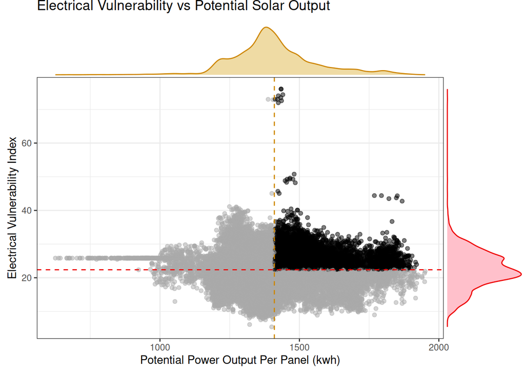

Figure 1. Scatterplot of Electrical Vulnerability Index (EVI) compared to potential output per panel from solar panels for each zip code. Densities of each variable are represented in the margins, and means for each variable are represented by dashed lines.

To analyze for well each zip code would perform as a microgrid candidate, each zip code was geocoded into population weighted latitude and longitude coordinates. Using the coordinates, monthly summaries of solar radiation, average wind speed, cumulative electrical demand, and average temperature were compiled to use as our raw features.

Each monthly summary as a raw data point was then fit to a sine wave, where the components of the sine wave including baseline, amplitude, and phase, were to be used by the clustering model. Reducing each modular month into a continuous sine wave for each feature is visualized below, with an example of monthly solar radiation for Portland, OR. Using the three features of the sine wave instead of the raw data allows the model to more easily compare zip codes by how seasonal they are, how their average month is, and when the seasonality is at its peak.

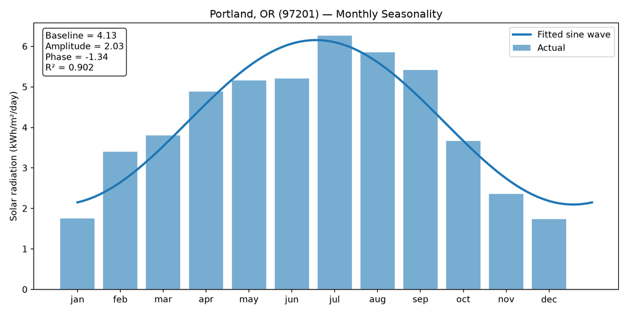

Figure 2. Fitted seasonal wave and actual monthly totals of solar radiation in Portland, OR.

Once the engineered features describing the seasonality of each metric were created, they were then scaled using scalars appropriate for each data type. Phase dimensions did not need scaling, demand required a log scale, and the rest of the features used a robust scaler that scales each distribution by its median rather than its mean.

With some features being colinear, for example seasonal peak in temperature and solar radiation, it was apparent our model would benefit from dimensionality reduction. We opted to use PCA to reduce our input dimension down to as few dimensions as possible to explain 95% of the variance in our data, which was found to be 9 dimensions.

These 9 dimensions were the final input for our clustering algorithm. Kmeans clustering was used to find similar zip codes based on the input features, and the best results from clustering was to produce 10 distinct clusters.

The resulting clusters were visualized using linear discriminant analysis, which shows generally how the clusters were chosen in terms of the features used, however the visualization is limited to only two dimensions and the dimensions chosen notably under represent demand, leading to some clusters to appear more entangled in the visualization than they are in the actual space used for clustering. Finally, the clusters were visualized on a geographic projection, simply plotting each zip code on a map for a relatively intuitive visual.

# Results

Attempts to compare our results to the existing microgrid installations in terms of their solar and wind installations were unsuccessful, presumably due to how differing microgrid installations have different goals. One microgrid might only be used as a battery infrastructure to maintain power to a hospital, and isn’t necessarily interested in renewable power sources. Some microgrids were in dense areas where a solar or wind installation might not be space effective. The confounding variables were very strong, and there was no notable relationship observed between renewable access and the observed installations.

Upon closer inspection the wind data in particular was very problematic, as there are many issues with using wind speed as an estimation for wind power. Our data source (“ERA5 Hourly Data on Single Levels from 1940 to Present” 2018) shows average wind speed, but wind power is proportional to the cube of wind speed. There are rough metrics for approximating wind power from average speed but our calculations showed that even the windiest areas were under performing expectations. Actual industry estimates are a very involved process that involve analysis at a more detailed scale than monthly averages across zip codes and this type of analysis is out of scope for this project.

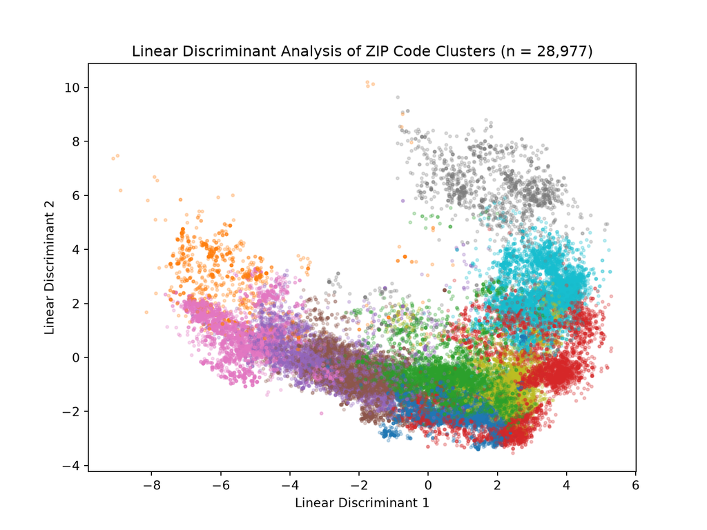

Figure 3. Kmeans clusters showing 10 clusters, projected in 2D by Linear Discriminant Analysis.

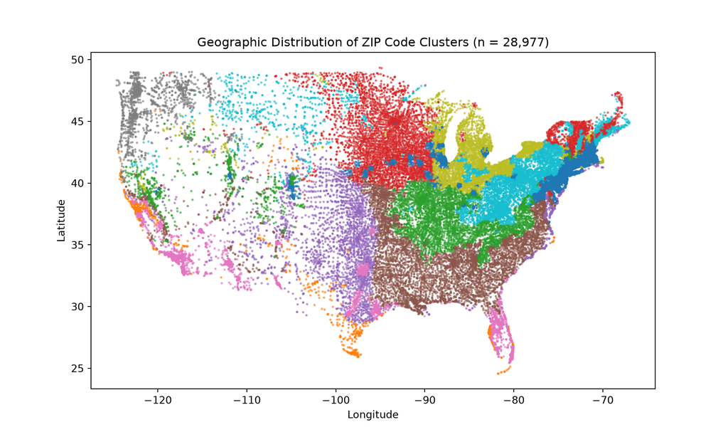

Figure 4. Same kmeans clusters, projected by each zip code’s latitude and longitude values. This projection shows a geographic representation of the 10 clusters.

# Conclusions

The decision to install a microgrid at any given location requires the consideration of many factors that are not within the scope of our project, such as the cost of implementation and the actual energy demand of the community or infrastructure in question. There are also many other possible power sources that we did not analyze, such as Combined Heat and Power (CHP) facilities, hydropower, or natural gas. Our results may provide a starting point for discussing microgrid installation, but should not be used to guarantee or discount the feasibility of installation at any given location. Future work will feature an emphasis on which locations have suitable means for powering a microgrid, at a feasible scale.

Not all locations are suitable candidates for DER-powered microgrid installation. Of the zip codes that are suitable based on our results, not all have the same potential for high photovoltaic output. We identified 10 clusters that categorized each zip code’s characteristics relevant to need and feasibility of DER-powered microgrid installation. With many zip codes having favorable features for a microgrid but not having one yet installed, it is hard to say from a data perspective that microgrids will definitively perform well in these locations, but certain clusters notably had high capacity factors for solar and similar demand profiles indicating the regions are likely solid candidates.

One notable restriction of our analysis was how poorly wind performed. The biggest issue with our assessment of wind is the scale we had to use for our framework. Wind power is proportionate to wind speed cubed, which means averaging wind speed across an entire month will severely undersell average wind power. Additionally, the installation location for wind power is usually a relatively complex process where expected wind gusts are maximized, for example placing a turbine in a naturally occurring wind tunnel between two mountains. Our analysis simply queried the average wind speed at the center of the zip code, which is very unlikely to be any given zip code’s best candidate location. Finally, our data source is simply not meant to capture wind power and is not likely to be a good representation for our purposes. Limitations on API calls and time forced us to under develop this portion of our analysis.

Future work would likely involve polling each given zip code’s area to find their most suitable locations for a turbine, subsequently polling many times to find average wind speed on a much more fine scale, at least hourly or better, and using that data to estimate wind power. This approach would be much more complex in terms of sampling, and much more demanding in terms of total data required.

Finally, with all these factors considered, we found that regions with high average wind speeds did not have a notable correlation with wind installations, and regions with high average solar potential did not have a correlation with solar installations. It was notable that by our estimations, a large amount of the continental US showed good solar potential and poor wind potential. There were many confounding variables that outweighed our analysis, such as some existing installations being battery only, some installations being in dense urban areas, and some installations being very small overall. All of these instances might cause a microgrid with good renewable energy potential to not utilize those resources.

# References

“ERA5 Hourly Data on Single Levels from 1940 to Present.” 2018. Climate Data Store, June. https://doi.org/10.24381/cds.adbb2d47.

Kerby, Jessica, Lee Miller, and Bethel Tarekegne. 2025. “Mapping the Electric Vulnerability Index: A Metric for Targeting Energy Storage Resilience Solutions.” *The Electricity Journal* 38 (3): 107498. https://doi.org/10.1016/j.tej.2025.107498.

*Microgrids Fact Sheet*. 2021. Better Buildings Solution Center, U.S. Department of Energy. https://www.energy.gov/sites/default/files/2021-03/Microgrids_Fact_Sheet_01.pdf.

Obika, Kodi, Wesley Cole, and Marie Rivers. 2025. *Hourly Electricity Demand Profiles for Each County in the Contiguous United States*. Open Energy Data Initiative (OEDI), National Laboratory of the Rockies (NLR). https://doi.org/10.25984/3366592.

“Onsite Energy Installation Database.” 2026. U.S. Department of Energy, ICF, Oak Ridge National Laboratory. https://www.onsite-energy-installations.ornl.gov.

*PRISM Weather Data*. 2026. Northwest Alliance for Computational Science & Engineering; Oregon State University. https://prism.oregonstate.edu/.

“PVWatts API.” n.d. National Laboratory of the Rockies; U.S. Department Of Energy. https://developer.nlr.gov/docs/solar/pvwatts/.

*Solar Integration Distributed Energy Resources and Microgrids Basics*. 2020. U.S. Department of Energy. https://www.energy.gov/cmei/systems/solar-integration-distributed-energy-resources-and-microgrids-basics.

“ZIP Code Database.” 2026. United States Postal Service, U.S. Census Bureau, Yahoo, IRS. https://www.unitedstateszipcodes.org/zip-code-database/.

“ZIP Code Population Weighted Centroids.” 2020. U.S. Department of Housing; Urban Development. https://catalog.data.gov/dataset/zip-code-population-weighted-centroids.